# Statistical Inference Simulation Project

Mark Bulkeley

April 2, 2016

## Overview

This report will explore the exponential distribution from both a theoretical and simulation standpoint, making use of the Central Limit Theorem. The report will use the stastical language R as the basis for the computations. It will be done in a reproducible fashion, so the reader can validate all of the results independently. All of the figures can be found in the appendix

## Simulations

Before we do simulations, we should note that we are going to compare the theoretical exponential distribution with a sampled one using a fixed lambda. The key parameters for our simulation are set below:

```r
lambda <- 0.2           # of exponential distribution
set.seed(seed = 39548)  # set for reproducibility
samples <- 1000         # number of simulations run
draws <- 40             # number of draws from exponential distribution for each simulation
```

To see what the theoretical distribution looks like, see Figure 1. You will note that the mean of the distribution is 5. In the sampling, we’ve taken the mean of 40 random draws. The results of the sampling can be seen in Figure 2. The code to do the sampling is compact, so we show it here:

```r
result <- do.call(rbind, lapply(1:samples, function(x){
    smpl <- rexp(n = draws, rate = lambda)
    return(data.table(mn=mean(smpl), vr=var(smpl), iteration=x))
}))
```

## Sample Mean versus Theoretical Mean

As mentioned before the theoretical mean is simply 1 / lambda, or in our case 5. The mean of sample means has come in very close to the theory at 5.013. That said, the distribution of means is reasonably wide and some estimates are lower than 3.5 and some higher than 7.

## Distribution: Approximately Normal

Specifically, here we are going to look at distribution of sample means to see if it approximates the normal distribution. First, we are going to look at it in terms of theoretical quantiles and realized quantiles for different p values and then look at a graphical view in Figure 4. First, let’s examine the following quantiles, via this code:

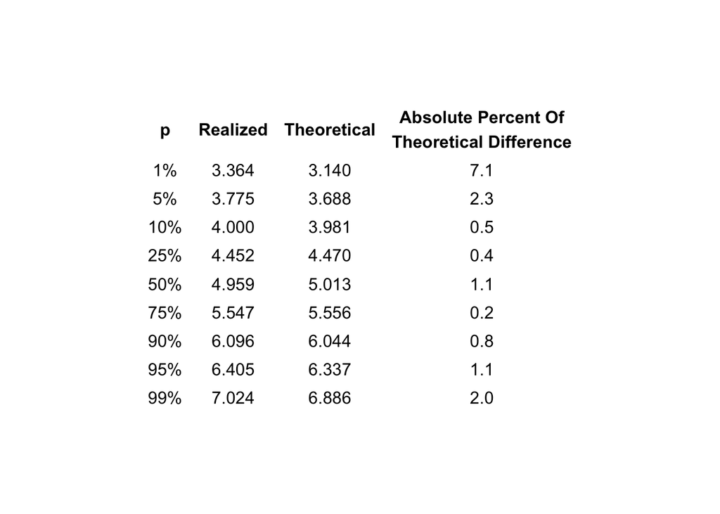

```r
p <- c(0.01, 0.05, 0.1, 0.25, 0.5, 0.75, 0.9, 0.95, 0.99)
quants <- data.table(p = p, Realized = quantile(result$mn, p),
                     Theoretical = qnorm(p, mean = mean(result$mn), sd = sd(result$mn)))
quants[, diff := round(100 * abs(Realized - Theoretical)/Theoretical, 1)]
grid.arrange(tableGrob(quants[, .(p = paste0(p*100, "%"),
                                  Realized = round(Realized,3),
                                  Theoretical = round(Theoretical,3),
                                  `Absolute Percent Of\nTheoretical Difference` = diff)],
                       rows = NULL, theme = ttheme_minimal()))
```

# Appendix: Figures

## Figure 1: Theoretical Exponential Distribution

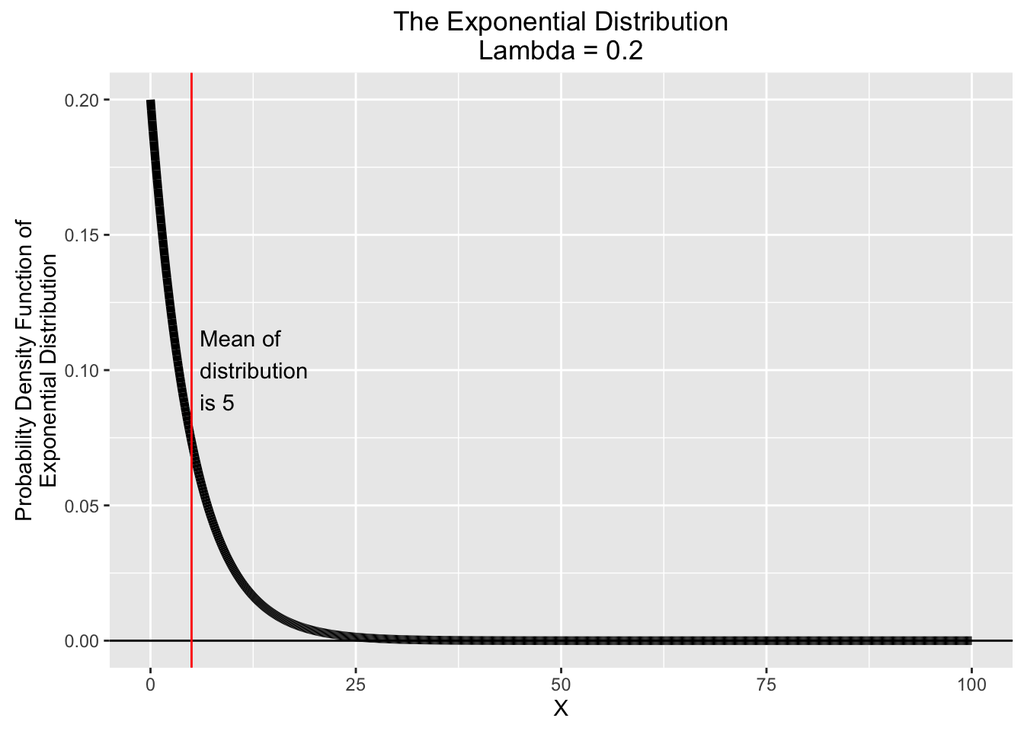

```r
plotRange <- 1:1e5/1e3
dt.plot <- data.table(x = plotRange, y = dexp(x=plotRange, rate = lambda))
ggplot(data=dt.plot, mapping=aes(x = x, y = y)) +
    geom_hline(yintercept = 0) +
    geom_line(lwd=2) +
    scale_x_continuous(name = "X") +
    scale_y_continuous(name = "Probability Density Function of\nExponential Distribution") +
    geom_vline(xintercept = 1 / lambda, col = "red") +
    annotate(geom = "text", x = 1 / lambda + 1, y = 0.1,
             label = paste0("Mean of\ndistribution\nis ", 1/lambda), hjust = 0) +
    ggtitle("The Exponential Distribution\nLambda = 0.2")
```

## Figure 2: Distribution of Means

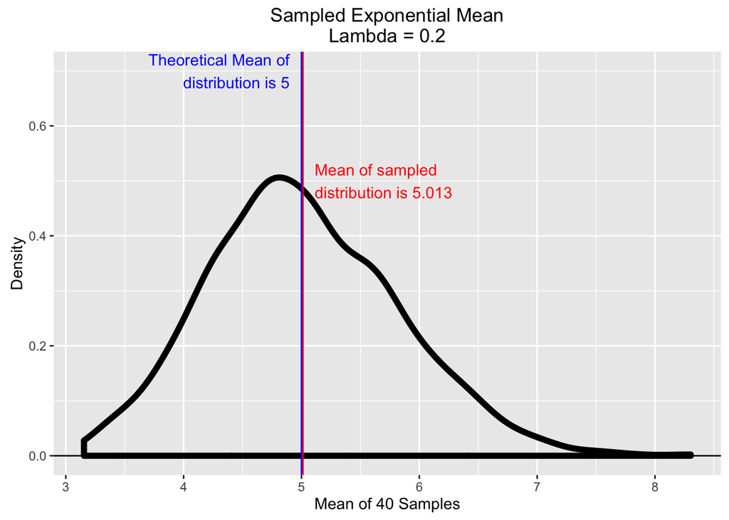

```r
ggplot(data=result, mapping=aes(x=mn)) +
    geom_hline(yintercept = 0) +
    geom_density(lwd = 2) +
    geom_vline(xintercept = mean(result$mn), col = "red") +
    annotate(geom = "text", x = mean(result$mn) + 0.1, y = 0.5,
             label = paste0("Mean of sampled\ndistribution is ",round(mean(result$mn),3)),
             hjust = 0, col = 'red') +
    geom_vline(xintercept = 1/lambda, col = "blue") +
    annotate(geom = "text", x = 1/lambda - 0.1, y = 0.7,
             label = paste0("Theoretical Mean of\ndistribution is ",1/lambda),
             hjust = 1, col = 'blue') +
    scale_y_continuous(name = "Density") +
    scale_x_continuous(name = "Mean of 40 Samples") +
    ggtitle("Sampled Exponential Mean\nLambda = 0.2")
```

## Figure 3: Distribution of Variance

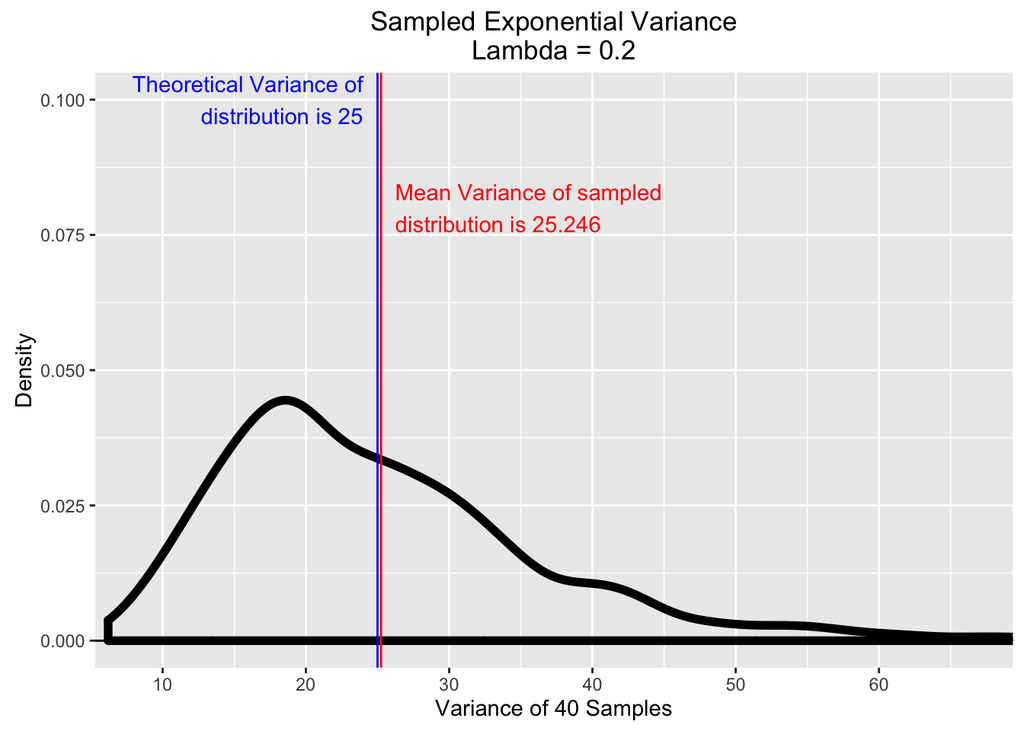

```r
ggplot(data=result, mapping=aes(x=vr)) +
    geom_hline(yintercept = 0) +
    geom_density(lwd = 2) +
    geom_vline(xintercept = mean(result$vr), col = "red") +
    annotate(geom = "text", x = mean(result$vr) + 1, y = 0.08,
             label = paste0("Mean Variance of sampled\ndistribution is ",round(mean(result$vr),3)),
             hjust = 0, col = 'red') +
    geom_vline(xintercept = (1/lambda)^2, col = "blue") +
    annotate(geom = "text", x = (1/lambda)^2 - 1, y = 0.1,
             label = paste0("Theoretical Variance of\ndistribution is ",(1/lambda)^2),
             hjust = 1, col = 'blue') +
    scale_y_continuous(name = "Density") +
    scale_x_continuous(name = "Variance of 40 Samples") +
    ggtitle("Sampled Exponential Variance\nLambda = 0.2") +
    coord_cartesian(xlim = quantile(result$vr, c(0.01, 0.99)))
```

## Figure 4: Normality of Sample Means

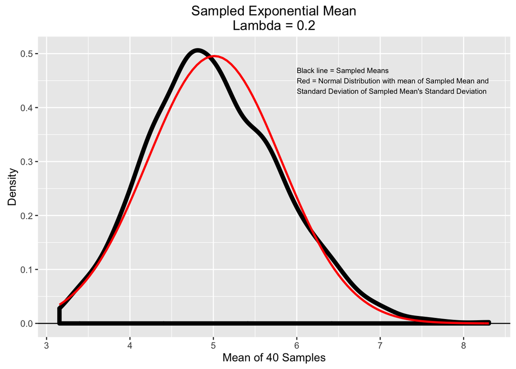

```r
ggplot(data=result, mapping=aes(x=mn)) +
    geom_hline(yintercept = 0) +
    geom_density(lwd = 2) +
    stat_function(fun=dnorm, args=list(mean=mean(result$mn), sd=sd(result$mn)),
                  size=1.0, col = "red") +
    scale_y_continuous(name = "Density") +
    scale_x_continuous(name = "Mean of 40 Samples") +
    ggtitle("Sampled Exponential Mean\nLambda = 0.2") +
    annotate(geom="text", x= 6, y = .45, label = paste0("Black line = Sampled Means\n",
        "Red = Normal Distribution with mean of Sampled Mean and \n",
        "Standard Deviation of Sampled Mean's Standard Deviation"), hjust = 0,
        size = 2.5)
```